# D17129392PSICAPart2RCommands

## 3. RESULTS

An alpha level .05 was adopted and Cohen’s conventions on effect size were adopted for all statistical tests (Field, Miles & Field, 2012).

### Hypothesis 1

H0: There is no correlation between HADS Anxiety Score and HADS Depression Score HA: There is a correlation between HADS Anxiety Score and HADS Depression Score

#### Scatterplot

[figure not shown]

### Hypothesis 2

H0: There is no correlation between HADS Anxiety Score and stress indicators HA: There is a correlation between HADS Anxiety Score and stress indicators

#### Scatterplot

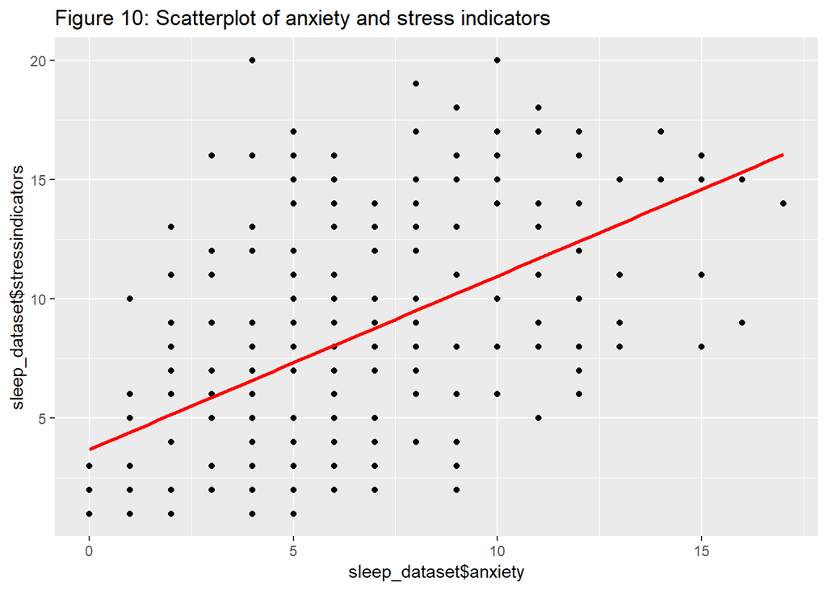

#### Reporting correlation

A Pearson product-moment correlation coefficient is computed to assess the relationship between Total HADS Anxiety and stress indicators. A strong positive correlation between Total HADS Anxiety and stress indicators was found (r = 0.52, n = 266, p < 0.05). Total HADS Anxiety and stress indicators have shared variance 27.04 of 27.04% and covariance of 8.7620883 . The p-value is less than the significance level of 0.05, which suggests that there is sufficient evidence to reject the null hypothesis that there is no correlation between anxiety and stress indicators. Based on the test, there is enough evidence to suggest that there is a strong correlation between Total HADS Anxiety and stress indicators and sufficient evidence to conclude that this relationship didn’t occur due to random chance.

### Hypothesis 3

H0: There is no correlation between HADS Depression Score and stress indicators HA: There is a correlation between HADS Depression Score and stress indicators

#### Scatterplot

[figure not shown]

### Hypothesis 4:

H0:There is no difference in HADS Anxiety Score for respondents who have trouble falling asleep and those who do not have a trouble falling asleep .

HA:There is a difference in HADS Anxiety Score for respondents who have trouble falling asleep and those who do not have a trouble falling asleep.

### Hypothesis 5:

H0:There is no difference in HADS Anxiety Score for respondents of different gender.

HA:There is a difference in HADS Anxiety Score for respondents of different gender.

### HYPOTHESIS 6

H0: The HADS Anxiety Score cannot be predicted by HADS Depression Score and stress indicators HA: The HADS Anxiety Score can be predicted by HADS Depression Score and stress indicators

#### Anxiety predicted by stress indicators and HADS Depression Score - BASE MODEL

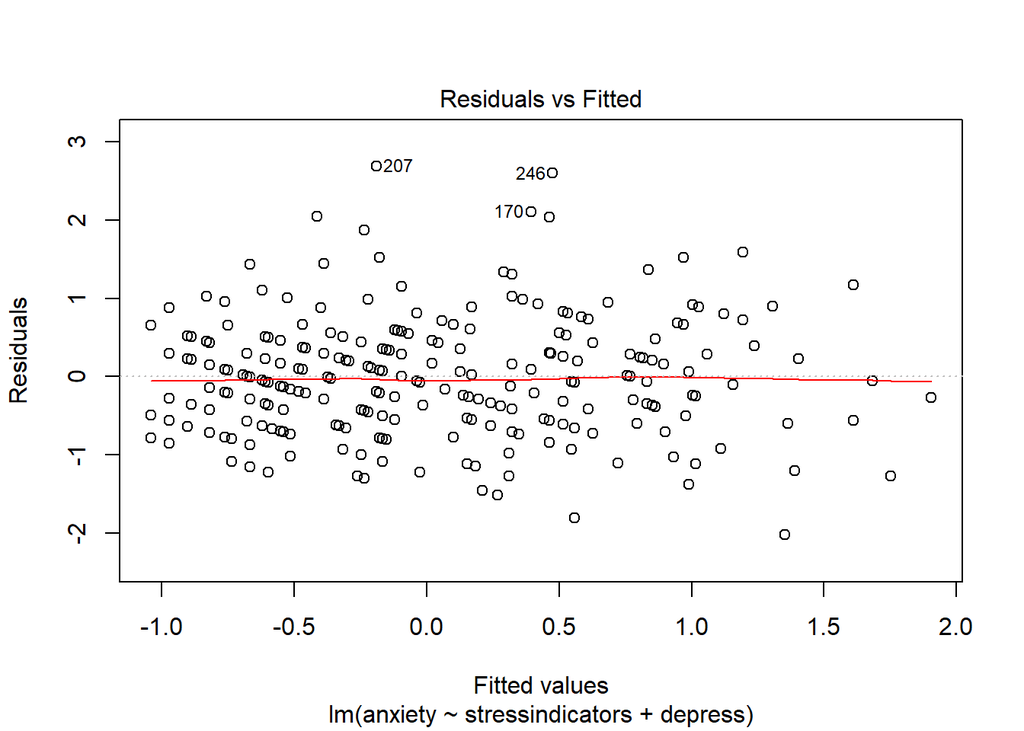

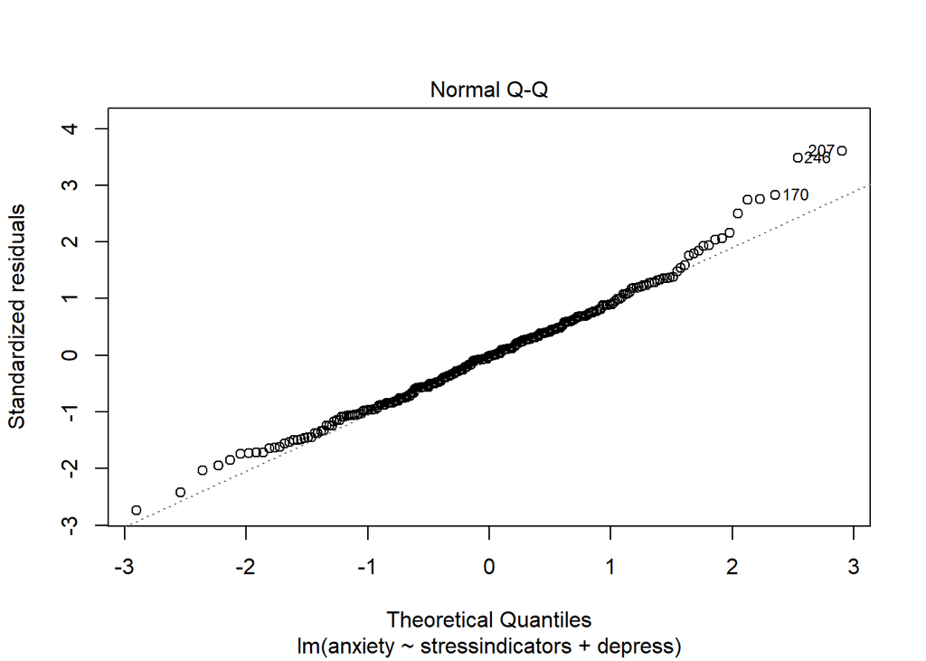

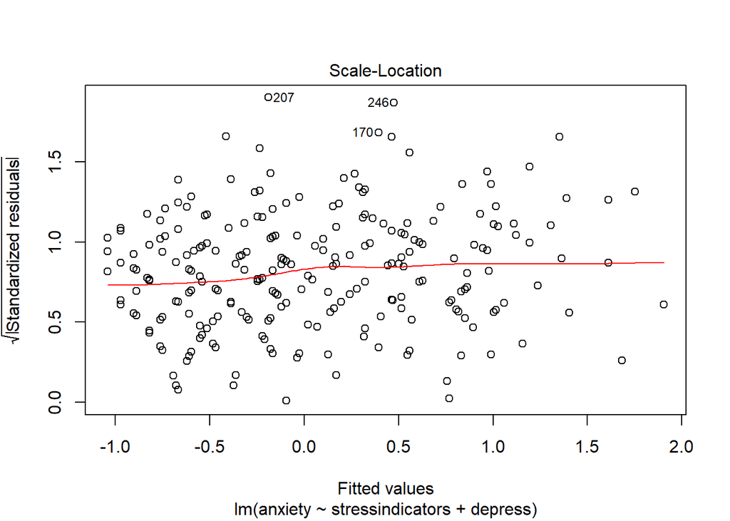

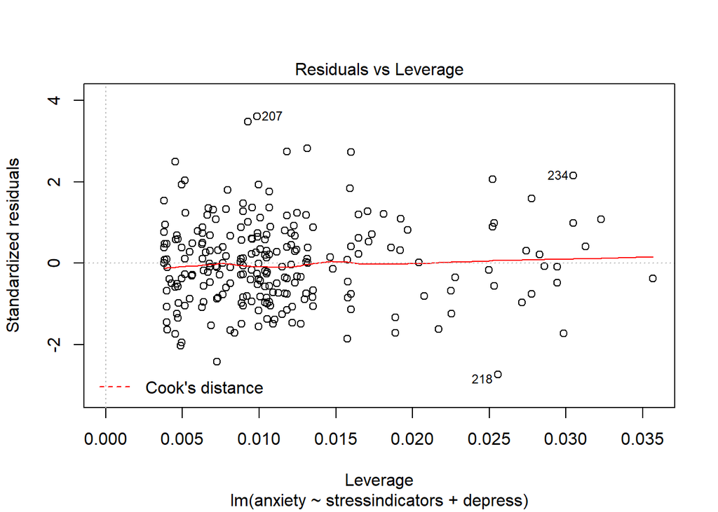

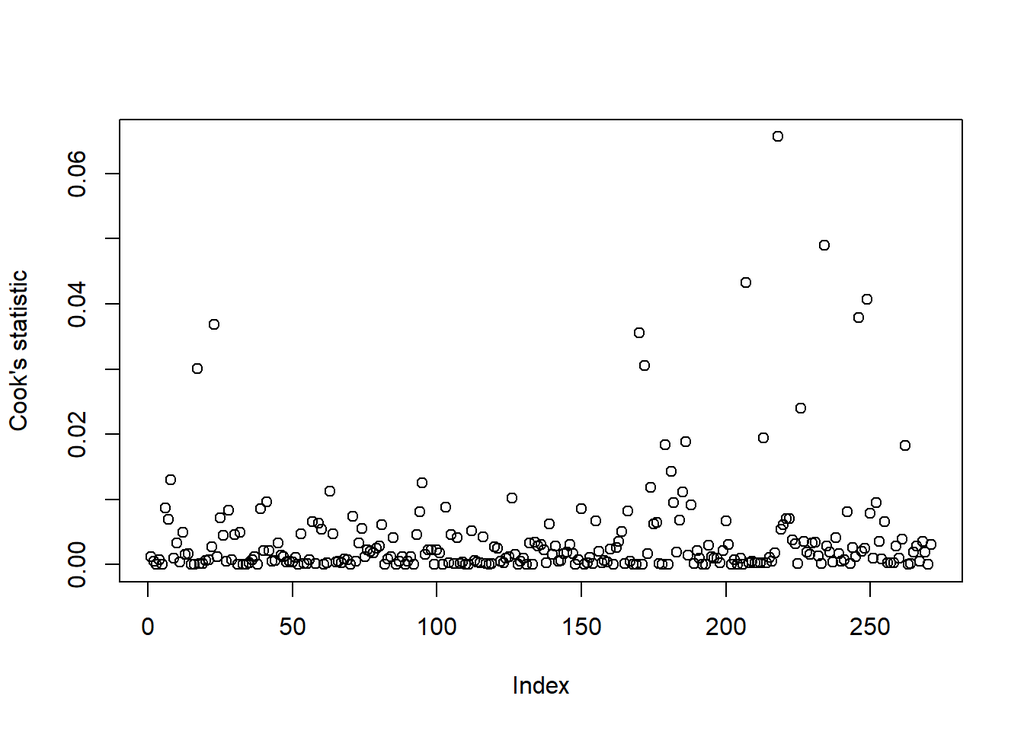

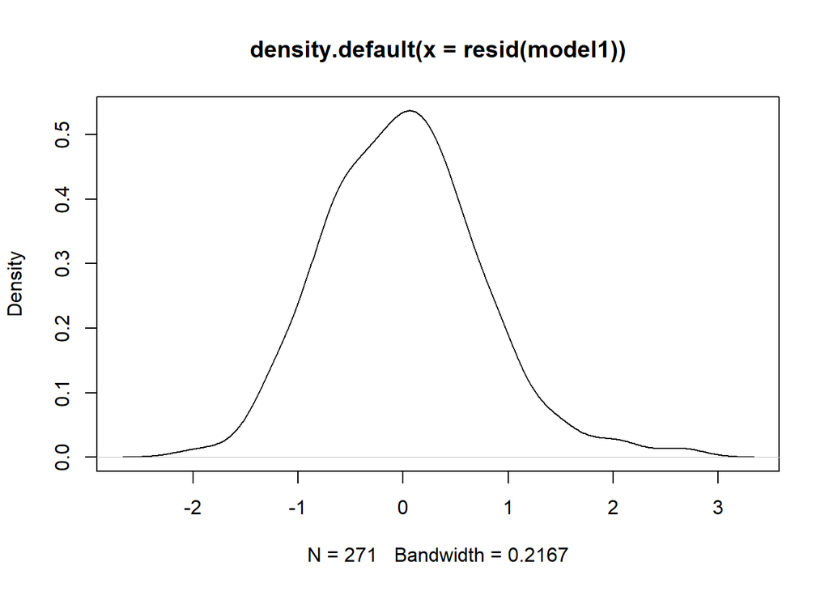

#### REPORT OF MODEL 1

The respondent’s standardised anxiety level increases 0.34 standard deviations for each standard deviation increase in stress indicators. The respondent’s standardised anxiety level increases 0.45 standard deviations for each standard deviation increase in depression level.

Both stress indicators (p<0.05) and depression level (p<0.05) were significant predictors of anxiety level.

Examination of the histogram, density plot, normal Q-Q plot of standardised residuals and the scatterplot of the dependent variable, anxiety level, and standardised residuals showed all points were close to the line. However, examination of the minimum and maximum value of standardised residuals showed that none could be considered to have undue influence (95% within limits of -3.29 to +3.29 and none with Cook’s distance > 1 as outlined in Field (2013) ) (Max Cooks Distance = 0.07).

Thus, there is sufficient evidence to reject the null hypothesis that the HADS Anxiety Score cannot be predicted by HADS Depression Score and stress indicators. Based on the results, we can conclude that the Depression level of a respondent and their stress indicator levels do have a strong significant influence on a respondent’s Anxiety levels.

### HYPOTHESIS 7

H0: The HADS Anxiety Score cannot be predicted by HADS Depression Score, stress indicators and Trouble falling asleep HA: The HADS Anxiety Score can be predicted by HADS Depression Score, stress indicators and Trouble falling asleep

### Model 2 - Anxiety predicted by stress indicators, depression level and trouble falling asleep

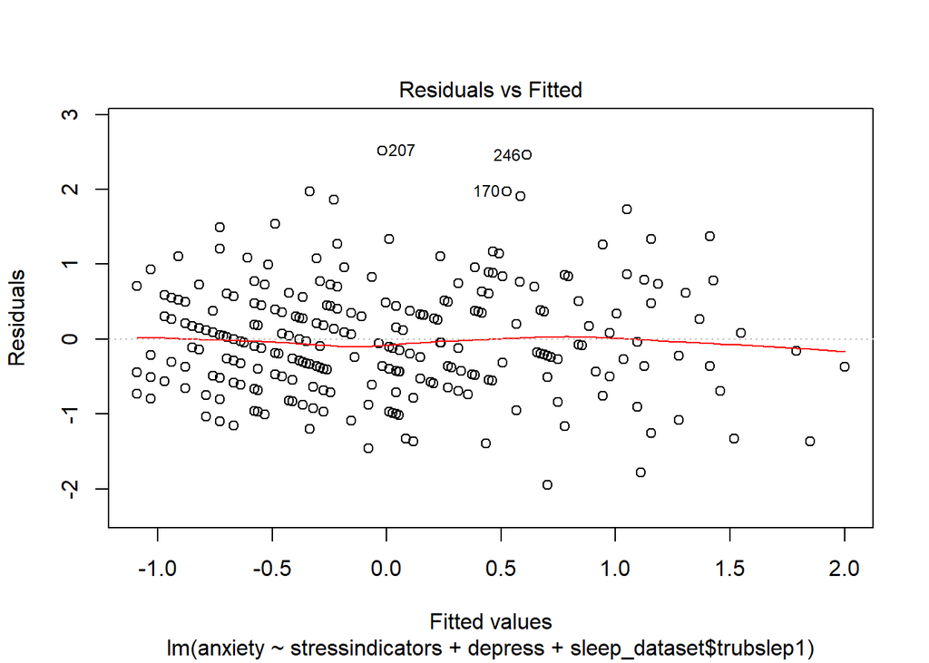

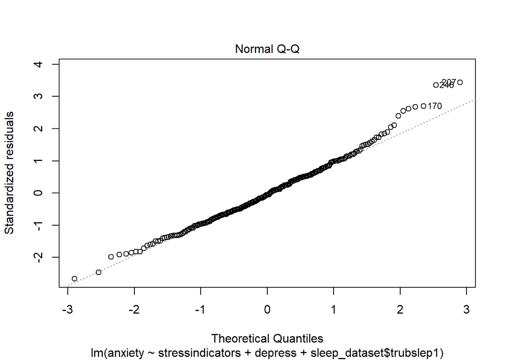

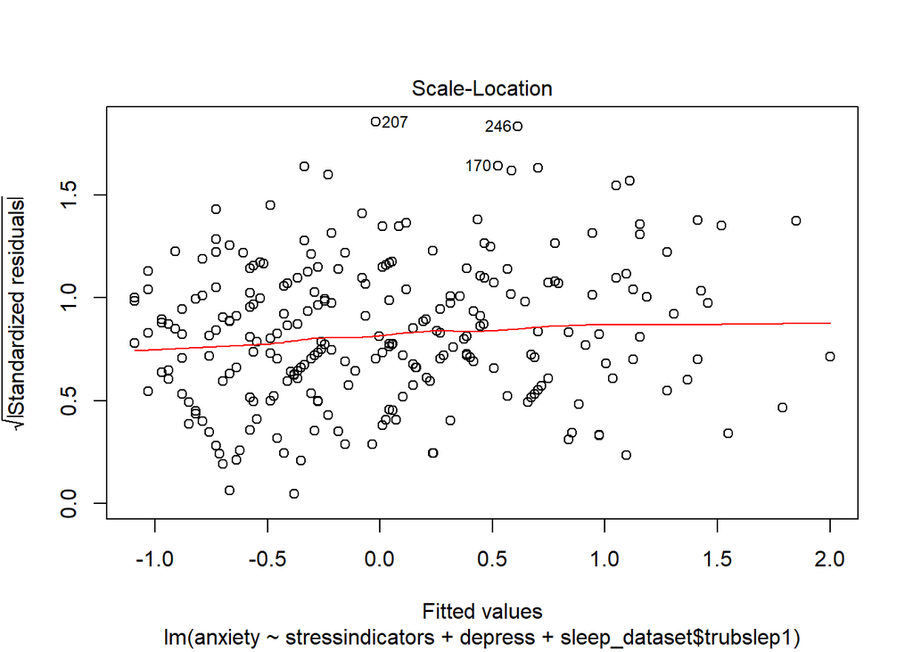

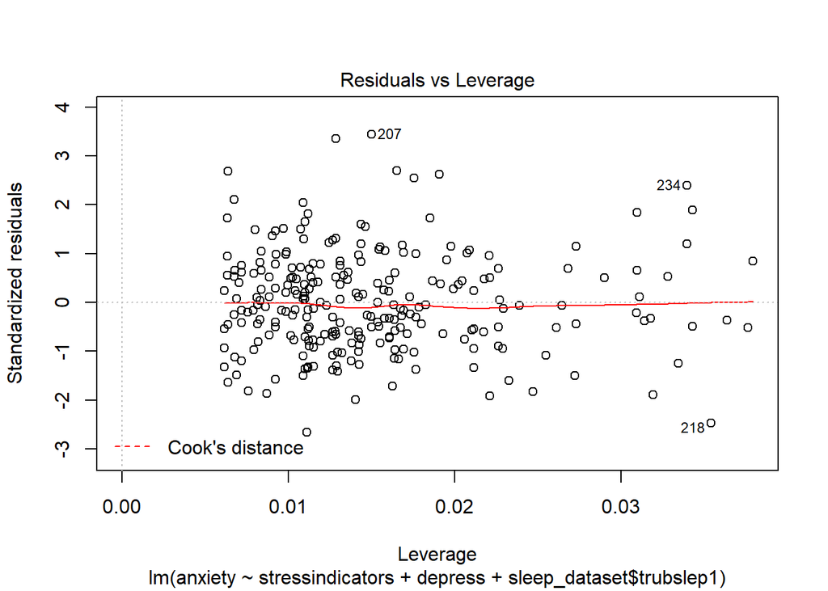

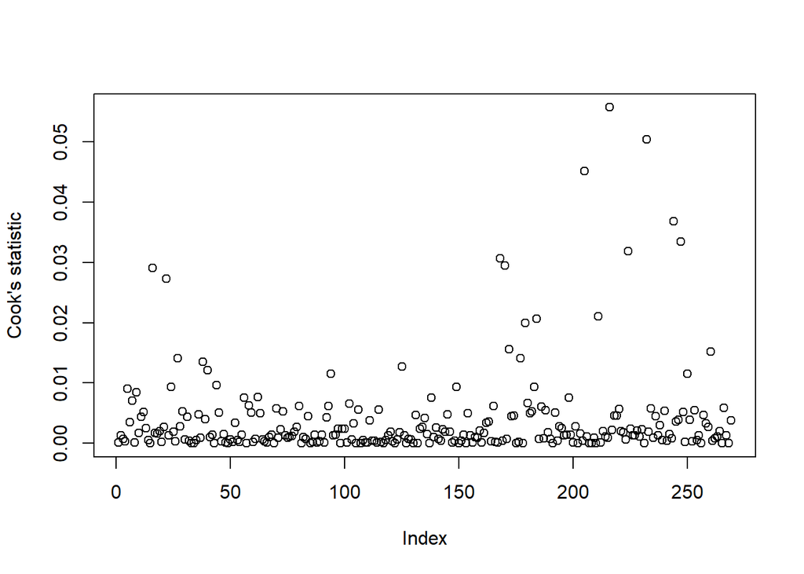

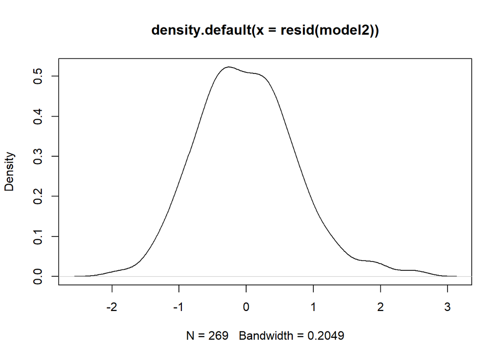

### REPORT OF MODEL 2

A multiple linear regression analysis was conducted to determine if a respondent’s anxiety level could be prdedicted by the continuous variables depression level, stress indicators (which is the sum of how much stress they felt in the last month and the impact on mood) and by the categorical variable trouble falling asleep.

The variable trouble falling asleep, which is represented by a categorical variable, was recoded as a dummy variable having values 1 for people having a trouble falling asleep and 2 for people who do not a trouble falling asleep.

The respondent’s standardised anxiety level increases 0.29 standard deviations for each standard deviation increase in stress indicators. The respondent’s standardised anxiety level increases 0.45 standard deviations for each standard deviation increase in depression level. The respondent’s standardised anxiety level increased 0.31 times for respondents who answered yes to the question if they have a trouble falling asleep.

All the variables stress indicators (p<0.05), depression level (p<0.05) and trouble sleeping (p<0.05) were significant predictors of anxiety level.

Examination of the histogram, density plot, normal Q-Q plot of standardised residuals and the scatterplot of the dependent variable, anxiety level, and standardised residuals showed all points were close to the line. However, examination of the minimum and maximum value of standardised residuals showed that none could be considered to have undue influence (95% within limits of -3.29 to +3.29 and none with Cook’s distance > 1 as outlined in Field (2013) ) (Max Cooks Distance = 0.06).

Tests to see if the data met the assumption of collinearity, indicated that multicollinearity was not a concern (Stressindicators, *tolerance* = 0.78, *VIF* = 1.13; Depress, *tolerance* = 0.84, *VIF* = 1.09; Trouble sleeping, *tolerance* = 0.92, *VIF* = 1.04 ) influence factor measures were within acceptable levels (*tolerance* > 0.4, *VIF* < 2.5) as outlined in Tarling (2008). The scatterplot of standardised residuals showed that the data met the assumptions of homogeneity of variance and linearity. The data also meets the assumption of non-zero variances of the predictors.

Thus, there is sufficient evidence to reject the null hypothesis that the HADS Anxiety Score cannot be predicted by HADS Depression Score, stress indicators and trouble falling asleep. Based on the results, we can conclude that the Depression level of a respondent, their stress indicator levels and based on a respondent’s trouble falling asleep, do have a significant influence on a respondent’s Anxiety levels.

### HYPOTHESIS 8

H0: The HADS Anxiety Score of a respondent cannot be predicted by HADS Depression Score, stress indicators, Trouble falling asleep and gender of the respondents.

HA: The HADS Anxiety Score of a respondent can be predicted by HADS Depression Score, stress indicators, Trouble falling asleep and gender of the respondents.

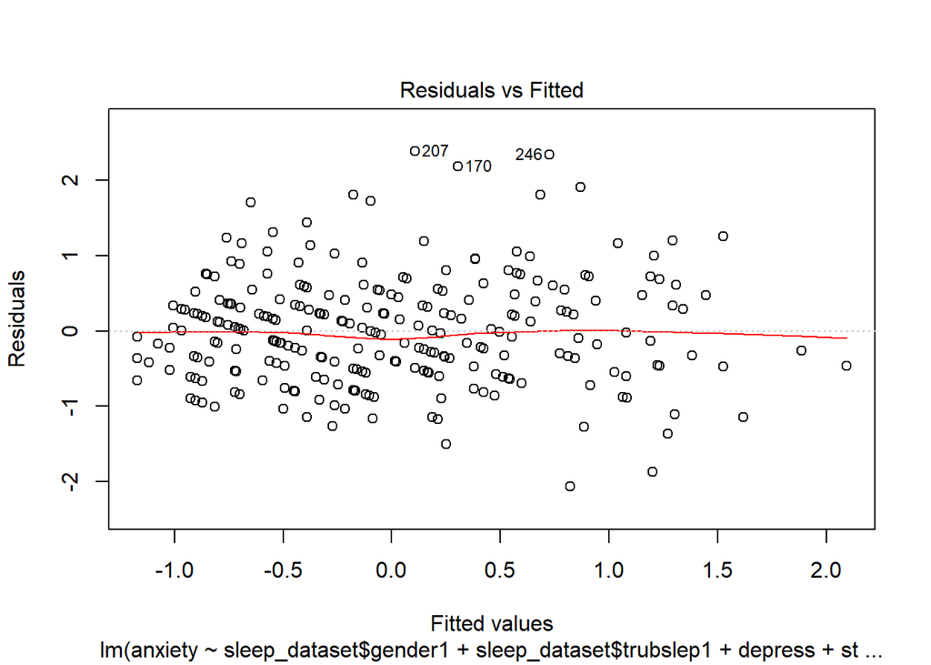

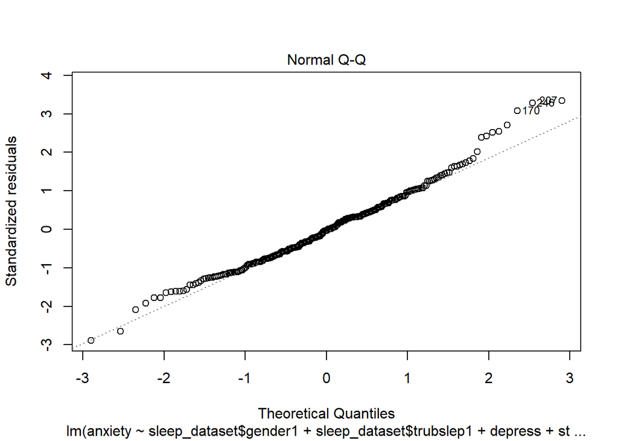

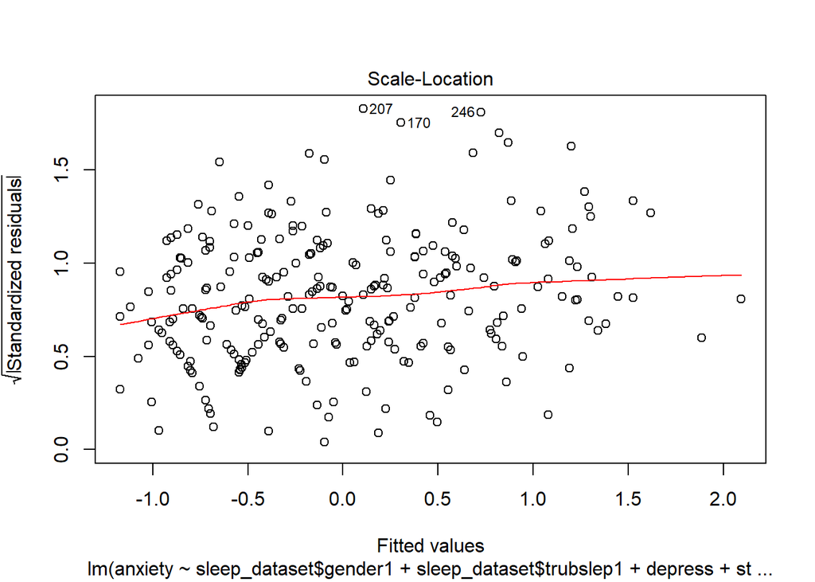

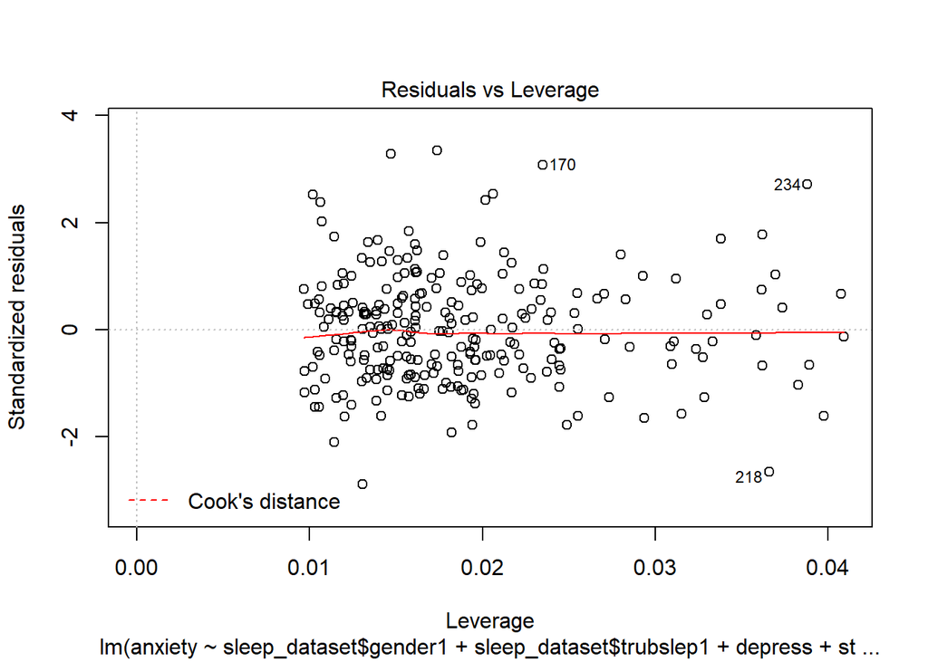

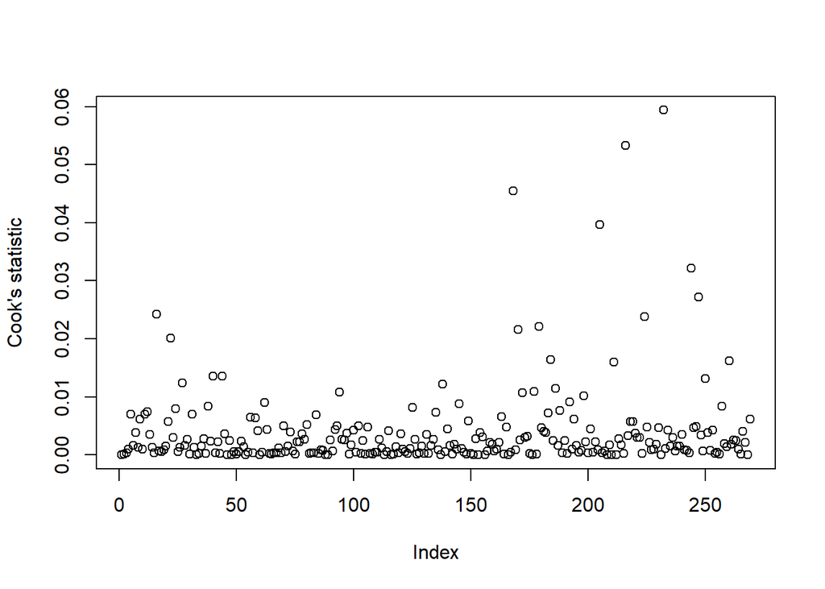

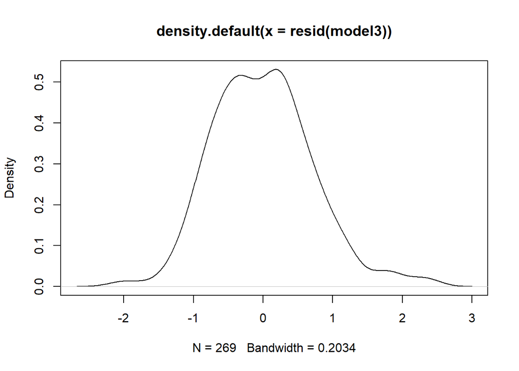

### REPORT OF MODEL 3

A multiple linear regression analysis was conducted to determine if a respondent’s anxiety level could be prdedicted by the continuous variables depression level, stress indicators (which is the sum of how much stress they felt in the last month and the impact on mood) and by the categorical variables trouble falling asleep and gender.

The variable gender which is represented by a categorical variable, was recoded as a dummy variable having values 1 as male and 2 for female.

The respondent’s standardised anxiety level increases 0.27 standard deviations for each standard deviation increase in stress indicators. The respondent’s standardised anxiety level increases 0.45 standard deviations for each standard deviation increase in depression level. The respondent’s standardised anxiety level increased 0.3 times for respondents who answered yes to the question if they have a trouble falling asleep. The respondent’s standardised anxiety level increased 0.33 times for female respondents.

All the variables stress indicators (p<0.05), depression level (p<0.05), trouble sleeping (p<0.05) and gender(p<0.05) were significant predictors of anxiety level.

Tests to see if the data met the assumption of collinearity, indicated that multicollinearity was not a concern (Stressindicators, *tolerance* = 0.77, *VIF* = 1.14; Depress, *tolerance* = 0.84, *VIF* = 1.09; Trouble sleeping, *tolerance* = 0.92, *VIF* = 1.04; Gender, *tolerance* = 0.97, *VIF* = 1.01 ) influence factor measures were within acceptable levels (*tolerance* > 0.4, *VIF* < 2.5) as outlined in Tarling (2008). The scatterplot of standardised residuals showed that the data met the assumptions of homogeneity of variance and linearity. The data also meets the assumption of non-zero variances of the predictors.

Thus, there is sufficient evidence to reject the null hypothesis that the HADS Anxiety Score cannot be predicted by HADS Depression Score, stress indicators, trouble falling asleep and gender. Based on the results, we can conclude that the Depression level of a respondent, their stress indicator levels, a respondent’s trouble falling asleep and their gender, do have a strong significant influence on a respondent’s Anxiety levels.

### Comparison of Models

```r
stargazer(model1,model2,model3, type="text")
```

```
##
## ============================================================================================
##                                               Dependent variable:
##                     ------------------------------------------------------------------------
##                                                     anxiety
##                               (1)                      (2)                     (3)
## --------------------------------------------------------------------------------------------
## gender12                                                                    0.324***
##                                                                              (0.089)
##
## stressindicators            0.338***                0.292***                0.268***
##                             (0.050)                  (0.051)                 (0.051)
##
## depress                     0.454***                0.450***                0.448***
##                             (0.050)                  (0.049)                 (0.048)
##
## trubslep11                                          0.317***                0.307***
##                                                      (0.096)                 (0.094)
##
## Constant                     -0.000                 -0.124**                -0.299***
##                             (0.045)                  (0.059)                 (0.075)
##
## --------------------------------------------------------------------------------------------
## Observations                  271                      269                     269
## R2                           0.445                    0.462                   0.488
## Adjusted R2                  0.441                    0.456                   0.480
## Residual Std. Error     0.748 (df = 268)        0.737 (df = 265)        0.720 (df = 264)
## F Statistic         107.334*** (df = 2; 268) 75.913*** (df = 3; 265) 62.818*** (df = 4; 264)
## ============================================================================================
## Note:                                                            *p<0.1; **p<0.05; ***p<0.01
```

## 4. Test Data

The sleep dataset was partitioned on 85% to a training dataset(n=228) and 15% to a test dataset (n=41).

#### Training dataset

A statistically significant regression equation was found for the training dataset model (F(4,223) = 54.01, p < 0.05) with an adjusted R2 of 0.48. A respondent’s anxiety score is equal to -0.26 + 0.28(stressindicators) + 0.44(depress) + 0.34(trouble sleeping) + 0.3(gender), where stress indicators and depression level are standardised continuous variables.

All the four variables were statistically significant in the training dataset with p-value < 0.05.

#### Test dataset

A statistically significant regression equation was found for the test dataset model (F(4,36) = 10.01, p < 0.05) with an adjusted R2 of 0.47. A respondent’s anxiety score is equal to -0.46 + 0.25(stressindicators) + 0.47(depress) + 0.03(trouble sleeping) + 0.38(gender), where stress indicators and depression level are standardised continuous variables.

The variables gender and trouble sleeping were not statistically significant with p-value > 0.05 and the variables stress indicators and depression were statistically significant with p-value < 0.05 .

## 5. Conclusion and Discussion

The aim of this research was to build multiple linear regression models capable of predicting HADS Anxiety Score better than just taking the mean.

All the variables of interest were checked for normality. Correlation and difference tests were performed to find if they were statistically significant or not. Based on the results, every correlation test and difference test proved to be statistically significant.

Once the significant variables were identified our baseline model was built using depression level, stress indicators as predictor variables. The model was statistically significant and was capable of predicting approximately 44.2% of the variance in anxiety levels, with all our predictors having a significant effect on the variable anxiety. Based on the results of the baseline model, our theoretical assumption that depression levels in a person and the stress they experience can be a predictor of anxiety present in them does seem to be valid and this model was significant where it was able to better predict rather than just by calculating the average.

For the second model, a categorical variable Trouble Falling Asleep was added as a predictor to the baseline model, which was again statistically significant with p < 0.05. The second model was capable of predicting approximately 45.7% of the variance in anxiety, with all our predictors having a significant effect. The model was able to predict the anxiety scores better when the respondents have a problem with falling asleep.

Thus, it can be concluded that the results of the third model is statistically significant and has a better predicting power and can be sufficiently stated that the depression levels of a person, their stress levels, a respondent’s trouble in falling asleep and their gender plays a significant role in predicting them experiencing anxiety levels.

With respect to future work, new variables from the dataset can be picked and added into the existing models to find if they are able to predict the anxiety levels of a respondent in a better way.

## 6. References

Nutt, D., Wilson, S., & Paterson L. (2008). Sleep disorders as core symptoms of depression. *PMC US National Library of Medicines*, 10(3), 329-336. Retrieved from: https://www.ncbi.nlm.nih.gov/pmc/articles/PMC3181883/

Al-Abri, M. (2015). Sleep Deprivation and Depression. *PMC US National Library of Medicines*, 15(1): e4-e6. Retrieved from: https://www.ncbi.nlm.nih.gov/pmc/articles/PMC4318605/

Shlarb, A., Reis, D. & Schroder, A. (2012). Sleep Characteristics, Sleep Problems, and Associations to Quality of Life among Psychotherapists. *Sleep Disorders*. Volume 2012, 1-7. Retrieved from: http://dx.doi.org/10.1155/2012/806913

Field, A., Miles, J., & Field, Z. (2012). *Discovering statistics using R. Sage publications.*

George, D. (2011). *SPSS for windows step by step: A simple study guide and reference, 17.0 update, 10/e. Pearson Education India.*